# Lesson 3

Notes:

### Pseudo-Facebook User Data

Notes: Using read.csv resulted in an file not found error

```r
pf <- read.delim('pseudo_facebook.tsv')
```

### Histogram of Users’ Birthdays

```r
# install.packages('ggplot2')
library(ggplot2)

names(pf)
```

```
##  [1] "userid"                "age"                   "dob_day"
##  [4] "dob_year"              "dob_month"             "gender"
##  [7] "tenure"                "friend_count"          "friendships_initiated"
## [10] "likes"                 "likes_received"        "mobile_likes"
## [13] "mobile_likes_received" "www_likes"             "www_likes_received"
```

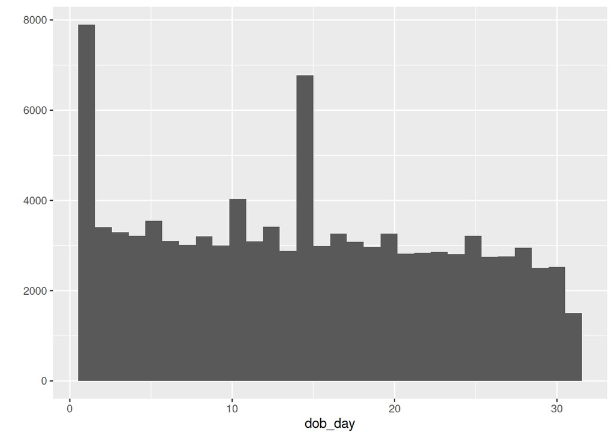

```r
qplot(x = dob_day, data = pf)
```

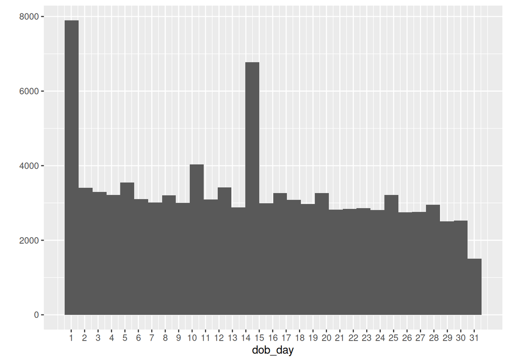

```r
qplot(x = dob_day, data = pf) +
  scale_x_continuous(breaks=1:31)
```

The same using ggplot

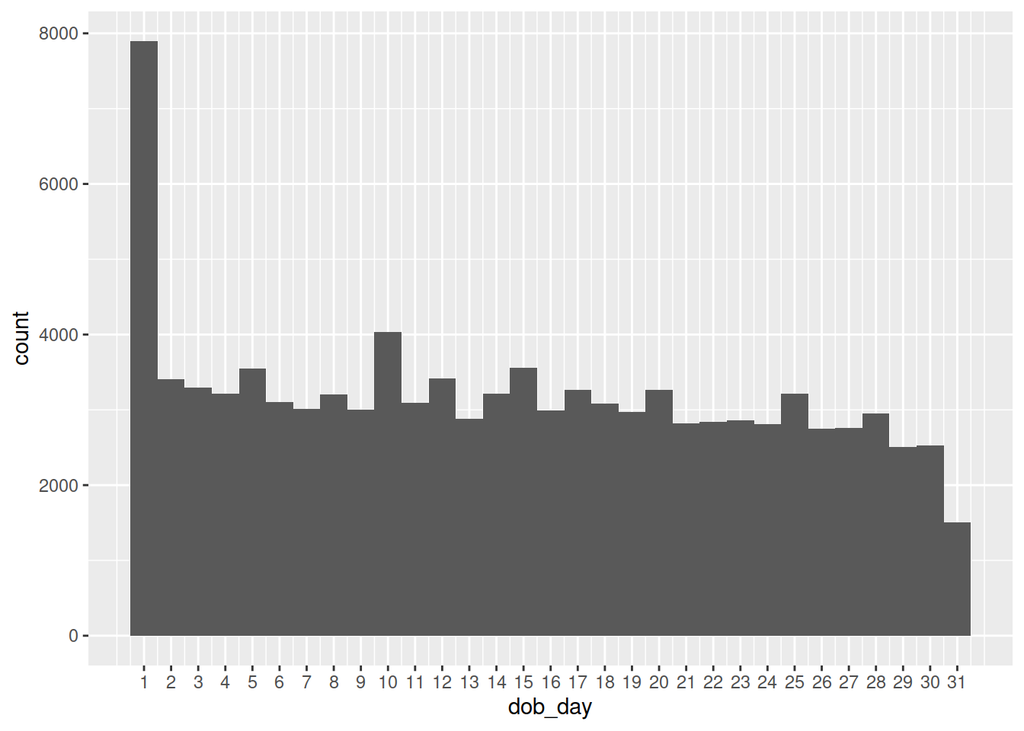

```r
ggplot(aes(x = dob_day), data = pf) +
  geom_histogram(binwidth = 1) +
  scale_x_continuous(breaks = 1:31)
```

### Faceting

Notes:

`facet_grid(vertical ~ horizontal)` can be used for multiple variables

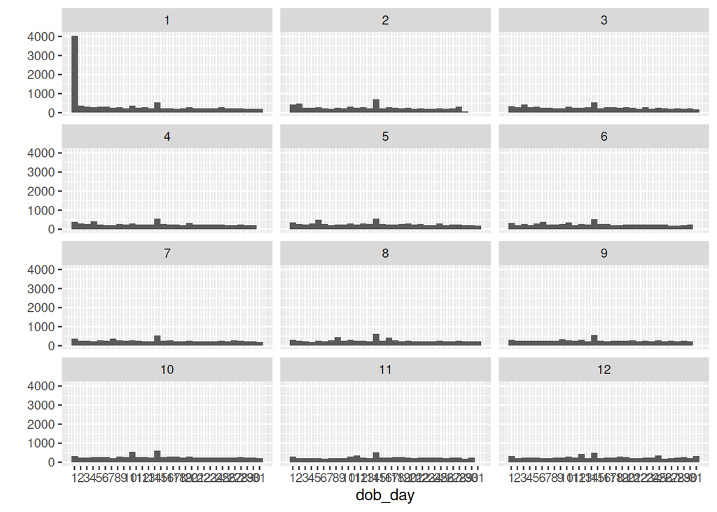

```r
qplot(x = dob_day, data = pf) +
  scale_x_continuous(breaks=1:31) +
  facet_wrap(~dob_month, ncol = 3)
```

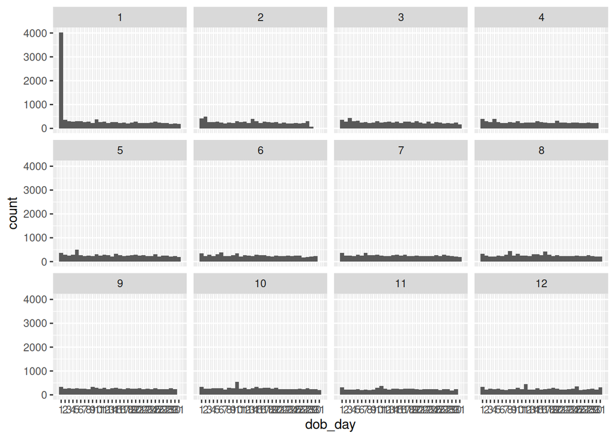

```r
ggplot(data = pf, aes(x = dob_day)) +
  geom_histogram(binwidth = 1) +
  scale_x_continuous(breaks = 1:31) +
  facet_wrap(~dob_month)
```

#### What code would you enter to create a histogram of friend counts?

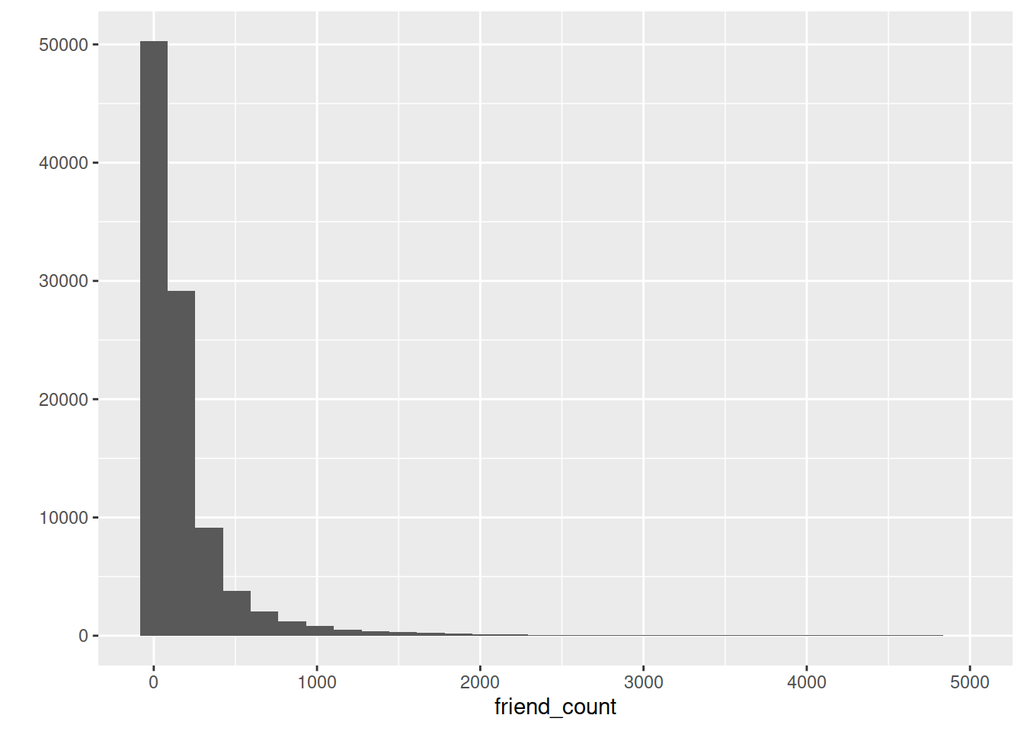

```r
qplot(x = friend_count, data = pf)
```

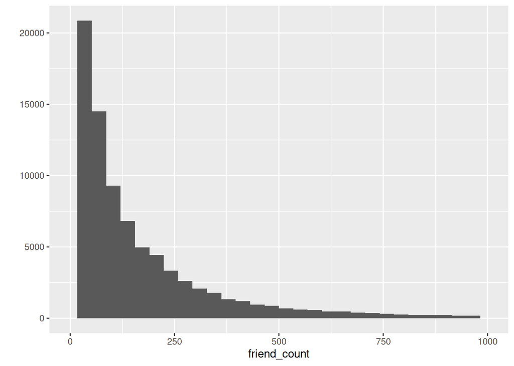

```r
qplot(x = friend_count, data = pf, xlim = c(0, 1000))
```

Or Equivalently:

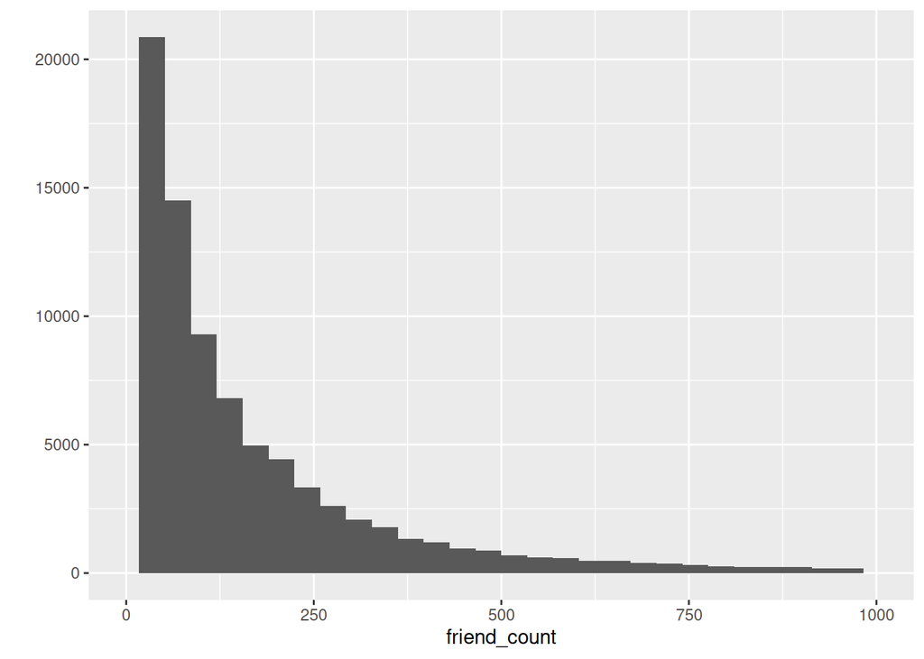

```r
qplot(x = friend_count, data = pf) +
  scale_x_continuous(limits = c(0, 1000))
```

Or with `ggplot()`

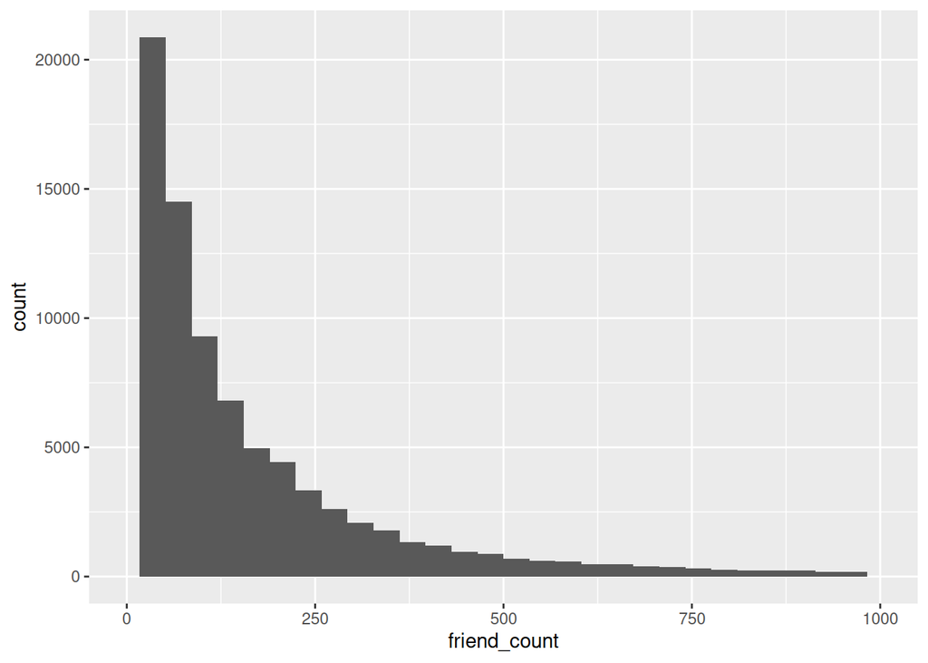

```r
ggplot(aes(x = friend_count), data = pf) +
  geom_histogram() +
  scale_x_continuous(limits = c(0, 1000))
```

## Adjusting the Bin Width

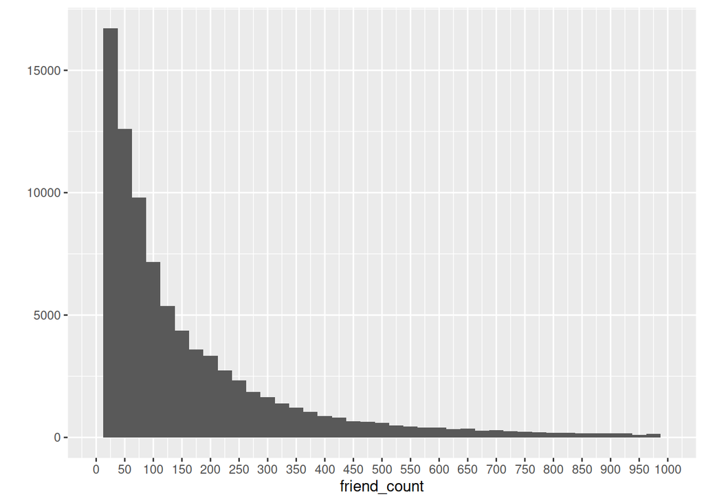

```r
qplot(x = friend_count, data = pf, binwidth = 25) +
  scale_x_continuous(limits = c(0, 1000), breaks = seq(0, 1000, 50))
```

### Exploring with Bin Width

Notes:

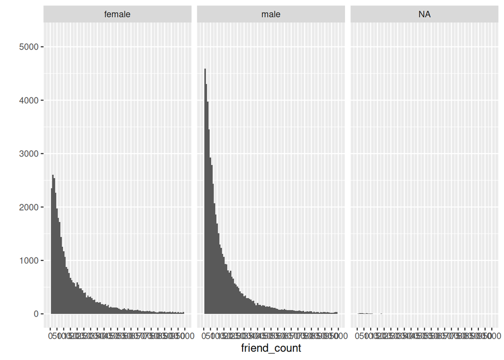

```r
qplot(x = friend_count, data = pf, binwidth = 10) +
  scale_x_continuous(limits = c(0, 1000), breaks = seq(0, 1000, 50)) +
  facet_wrap(~gender)
```

Remove NAs

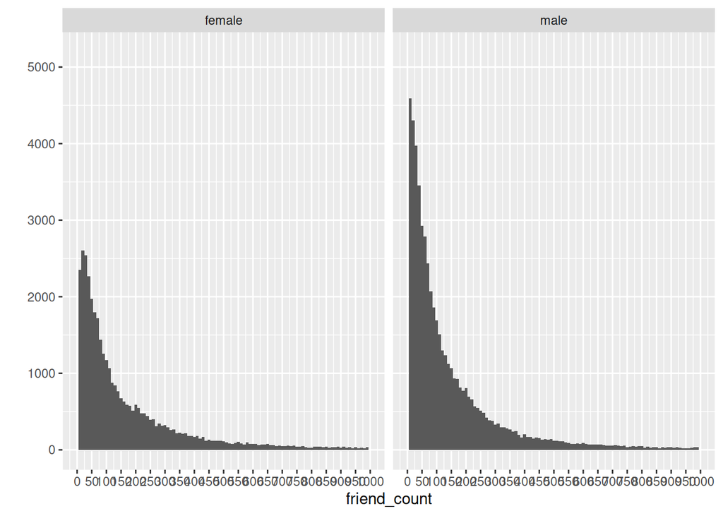

```r
qplot(x = friend_count, data = subset(pf, !is.na(gender)), binwidth = 10) +
  scale_x_continuous(limits = c(0, 1000), breaks = seq(0, 1000, 50)) +
  facet_wrap(~gender)
```

With `ggplot()`

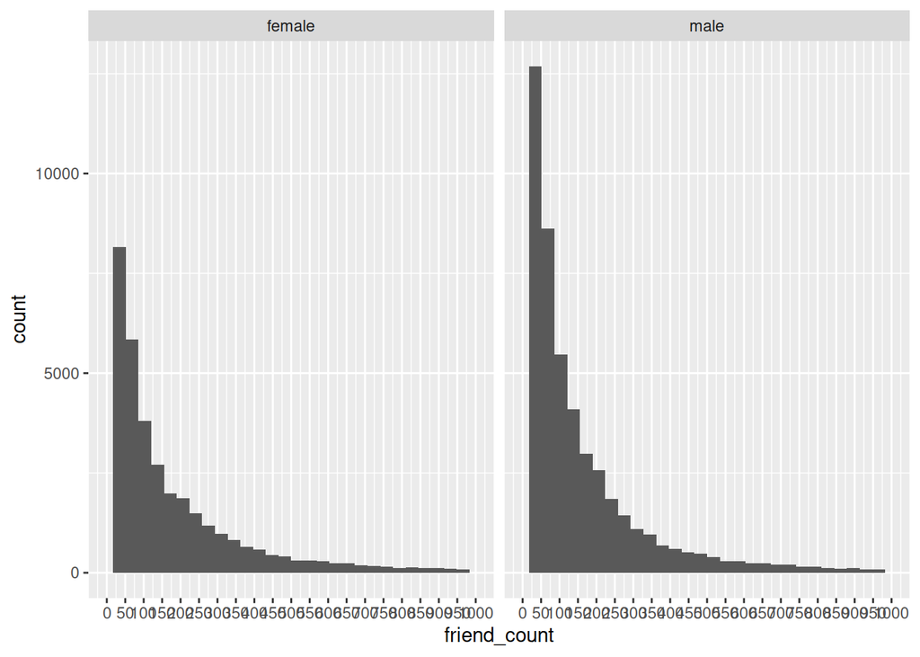

```r
ggplot(aes(x = friend_count), data = subset(pf, !is.na(gender))) +
  geom_histogram() +
  scale_x_continuous(limits = c(0, 1000), breaks = seq(0, 1000, 50)) +
  facet_wrap(~gender)
```

### Faceting Friend Count

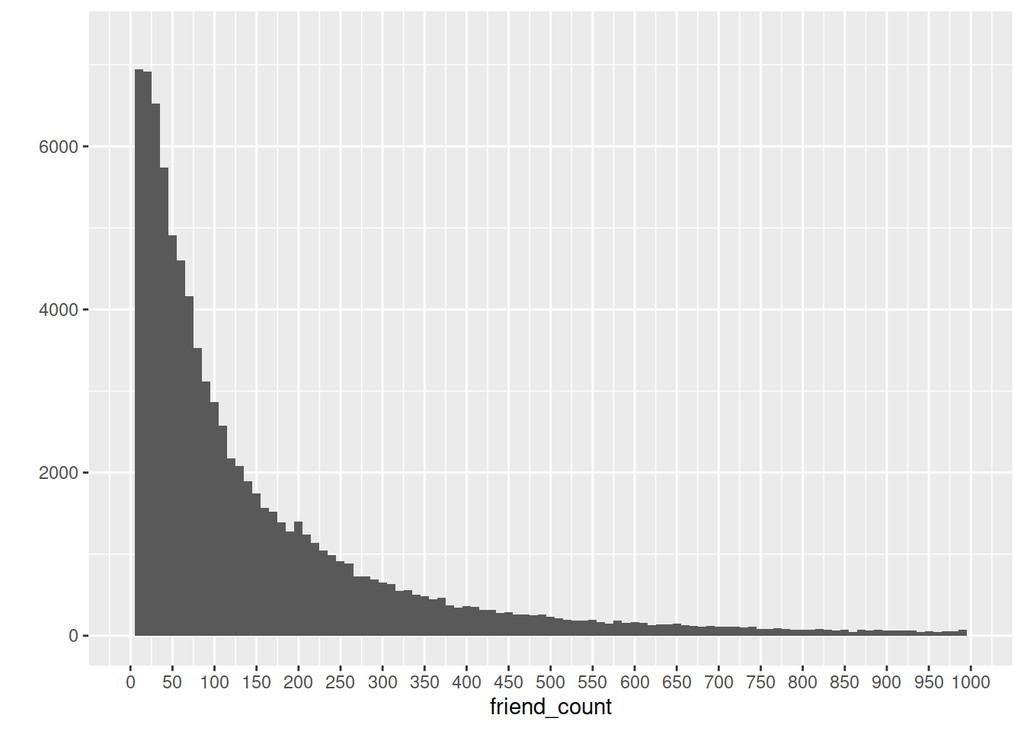

```r
# What code would you add to create a facet the histogram by gender?
# Add it to the code below.
qplot(x = friend_count, data = pf, binwidth = 10) +
  scale_x_continuous(limits = c(0, 1000),
                     breaks = seq(0, 1000, 50))
```

### Omitting NA Values

Notes:

### Statistics ‘by’ Gender

Notes:

```r
table(pf$gender)
```

```
##
## female   male
##  40254  58574
```

# by() data a variable, a categorical variable and a function

```r
by(pf$friend_count, pf$gender, summary)
```

```
## pf$gender: female
##    Min. 1st Qu.  Median    Mean 3rd Qu.    Max.
##       0      37      96     242     244    4923
## ------------------------------------------------------------
## pf$gender: male
##    Min. 1st Qu.  Median    Mean 3rd Qu.    Max.
##       0      27      74     165     182    4917
```

### Tenure

Notes:

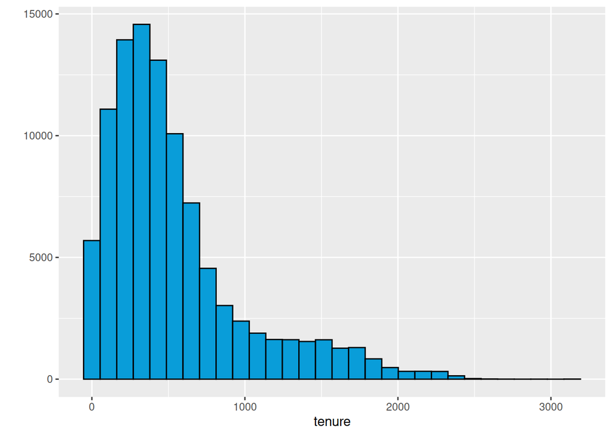

```r
qplot(x = tenure, data = pf,
      color = I('black'), fill = I('#099DD9'))
```

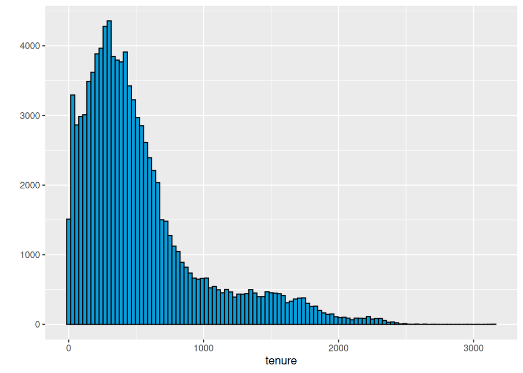

```r
qplot(x = tenure, data = pf, binwidth = 30,
      color = I('black'), fill = I('#099DD9'))
```

`ggplot()`

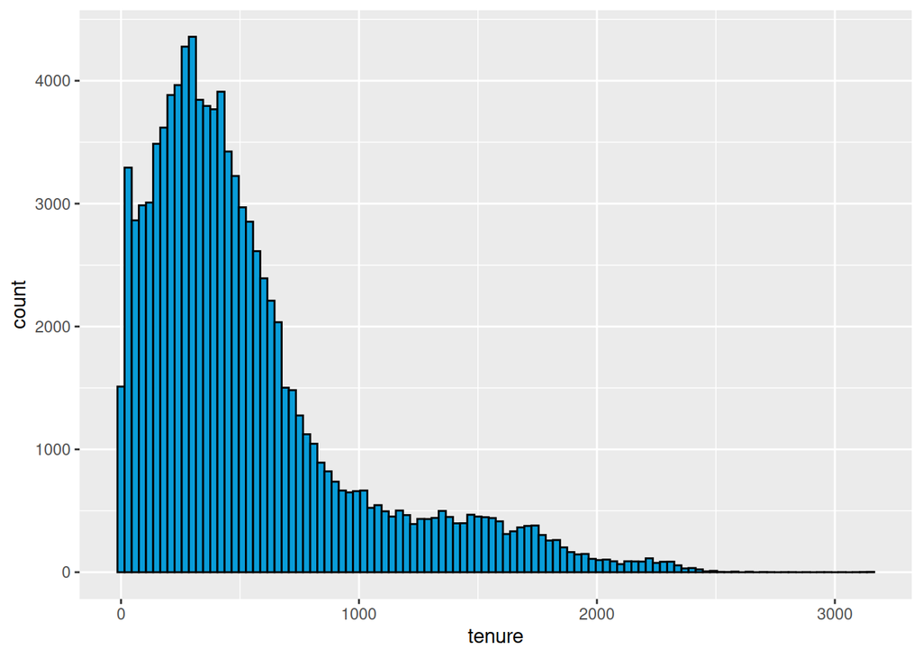

```r
ggplot(aes(x = tenure), data = pf) +
  geom_histogram(binwidth = 30, color = 'black', fill = '#099DD9')
```

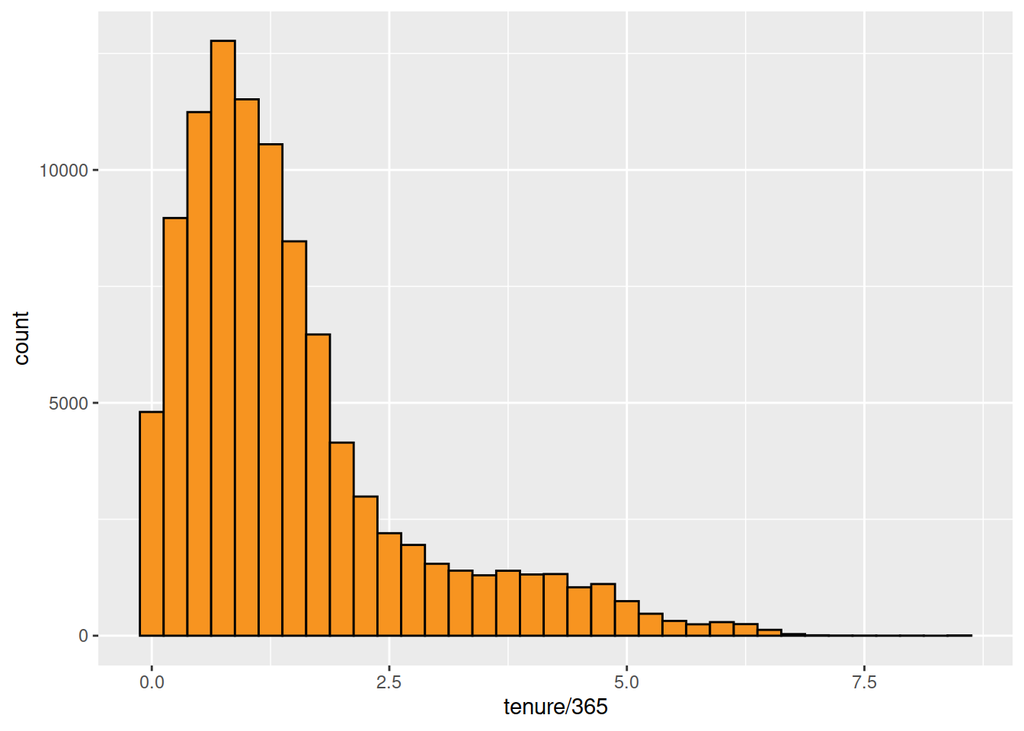

```r
ggplot(aes(x = tenure/365), data = pf) +
  geom_histogram(binwidth = .25, color = 'black', fill = '#F79420')
```

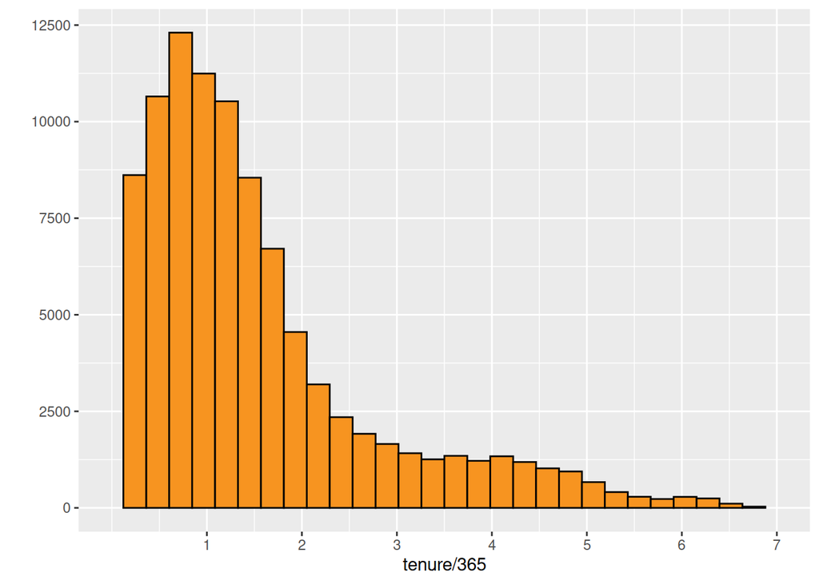

```r
qplot(x = tenure/365, data = pf,
      color = I('black'), fill = I('#F79420')) +
  scale_x_continuous(breaks = seq(1, 7, 1), lim = c(0,7))
```

### Labeling Plots

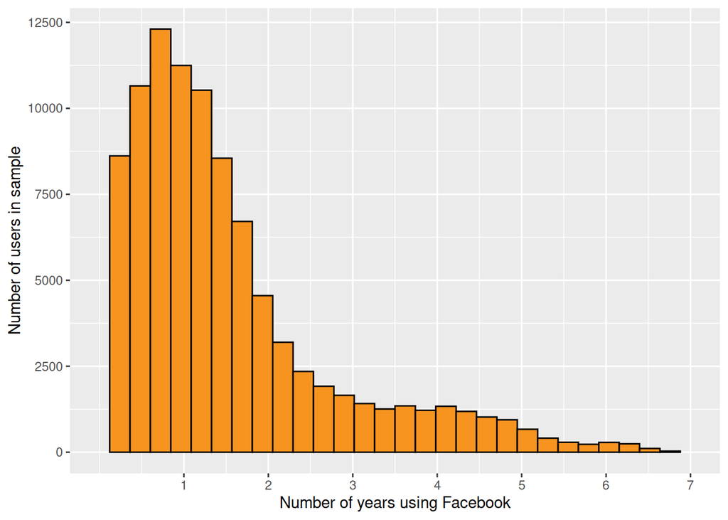

```r
qplot(x = tenure/365, data = pf,
      xlab = 'Number of years using Facebook',
      ylab = 'Number of users in sample',
      color = I('black'), fill = I('#F79420')) +
  scale_x_continuous(breaks = seq(1, 7, 1), lim = c(0,7))
```

### User Ages

Notes:

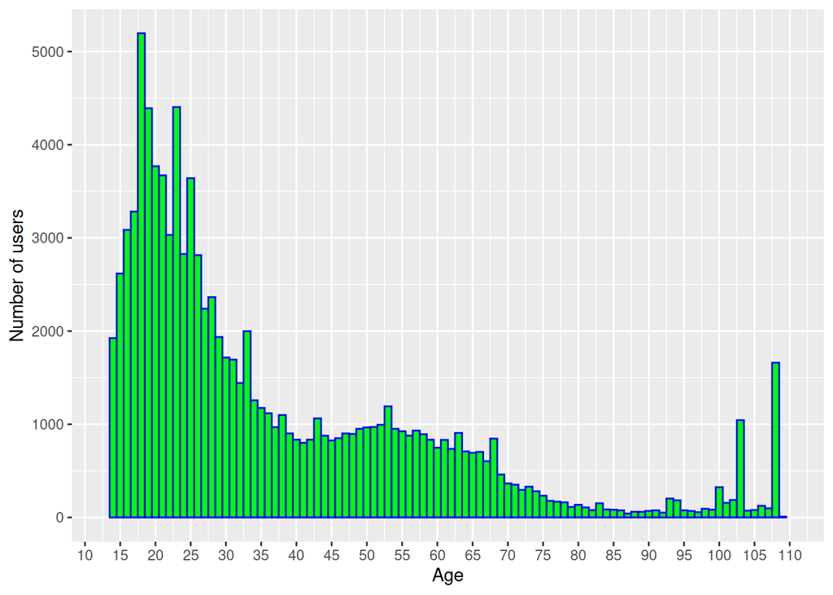

```r
qplot(x = age, data = pf, binwidth = 1,
      xlab = 'Age', ylab = 'Number of users',
      color = I('blue'), fill = I('green')) +
  scale_x_continuous(breaks = seq(0, 110, 5), lim=c(13,110))
```

In ggplot

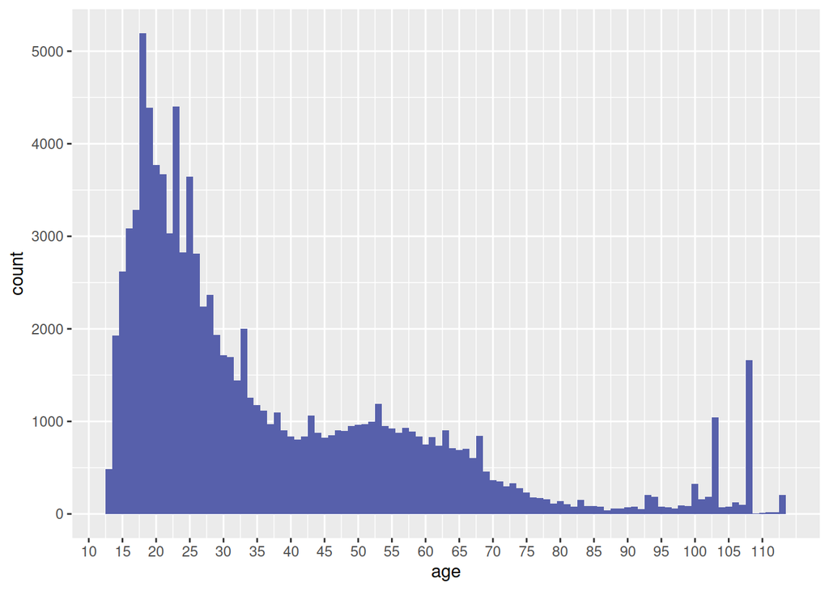

```r
ggplot(aes(x = age), data = pf) +
  geom_histogram(binwidth = 1, fill = '#5760AB') +
  scale_x_continuous(breaks = seq(0, 113, 5))
```

### Transforming Data

Data sets with long tails should be transformed by eg. log to better understand the data/turn it to a more normal distribution

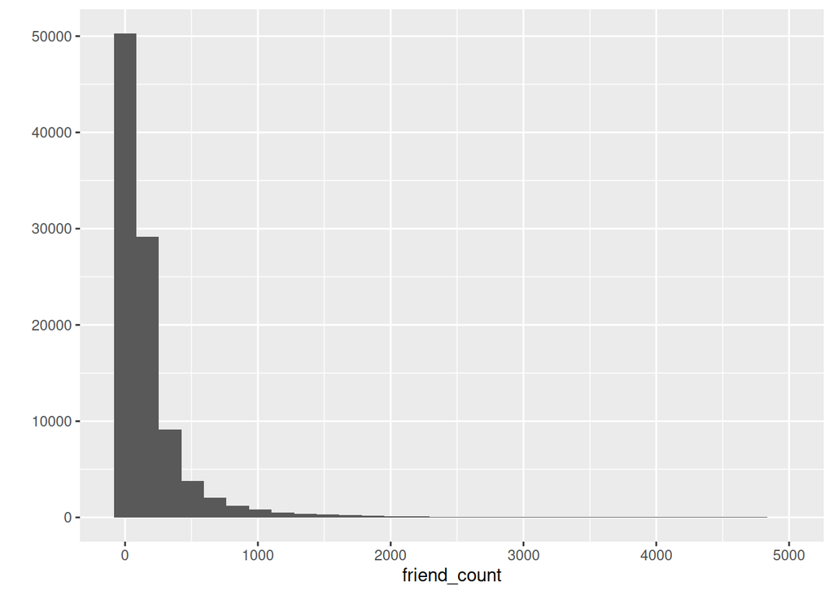

```r
qplot(x = friend_count, data = pf)
```

```r
summary(pf$friend_count)
```

```
##    Min. 1st Qu.  Median    Mean 3rd Qu.    Max.
##     0.0    31.0    82.0   196.4   206.0  4923.0
```

```r
summary(log10(pf$friend_count))
```

```
##    Min. 1st Qu.  Median    Mean 3rd Qu.    Max.
##    -Inf   1.491   1.914    -Inf   2.314   3.692
```

We can’t use log of 0 so:

```r
summary(log10(pf$friend_count + 1))
```

```
##    Min. 1st Qu.  Median    Mean 3rd Qu.    Max.
##   0.000   1.505   1.919   1.868   2.316   3.692
```

Another possible transformation is sqrt

```r
summary(sqrt(pf$friend_count + 1))
```

```
##    Min. 1st Qu.  Median    Mean 3rd Qu.    Max.
##   1.000   5.657   9.110  11.181  14.387  70.171
```

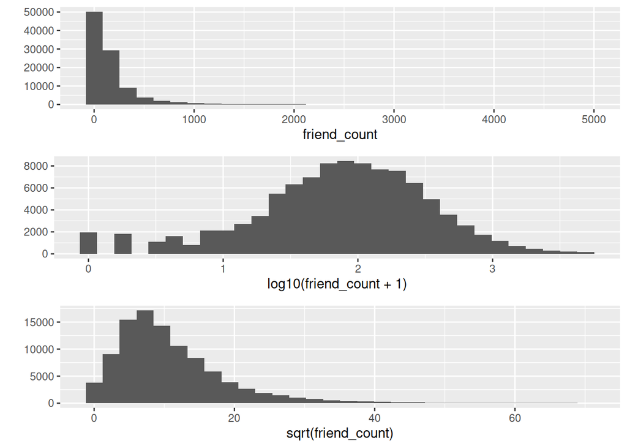

```r
library('gridExtra')
p1 <- qplot(x = friend_count, data = pf)
p2 <- qplot(x = log10(friend_count + 1), data = pf)
p3 <- qplot(x = sqrt(friend_count), data = pf)

grid.arrange(p1, p2, p3, ncol = 1)
```

With ggplot()

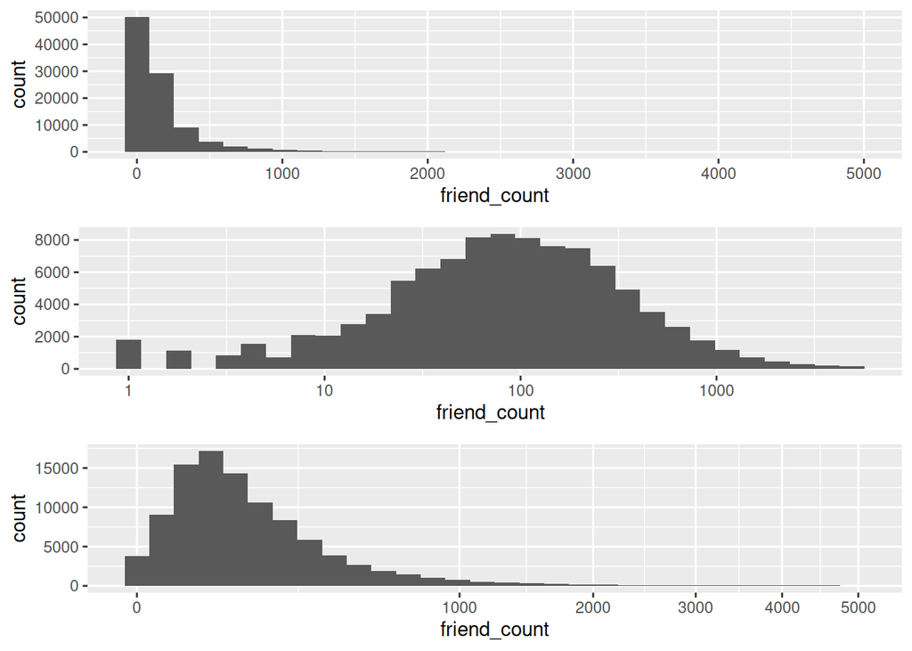

```r
p1 <- ggplot(aes(x = friend_count), data = pf) +
  geom_histogram()
p2 <- p1 + scale_x_log10()
p3 <- p1 + scale_x_sqrt()

grid.arrange(p1, p2, p3, ncol = 1)
```

### Add a Scaling Layer

Notes:

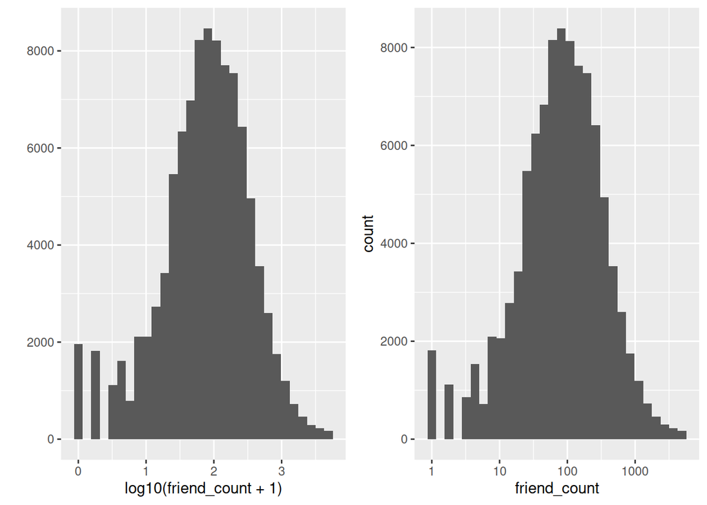

```r
logScale <- qplot(x = log10(friend_count + 1), data = pf)

countScale <- ggplot(aes(x = friend_count), data = pf) +
  geom_histogram() +
  scale_x_log10()

grid.arrange(logScale, countScale, ncol = 2)
```

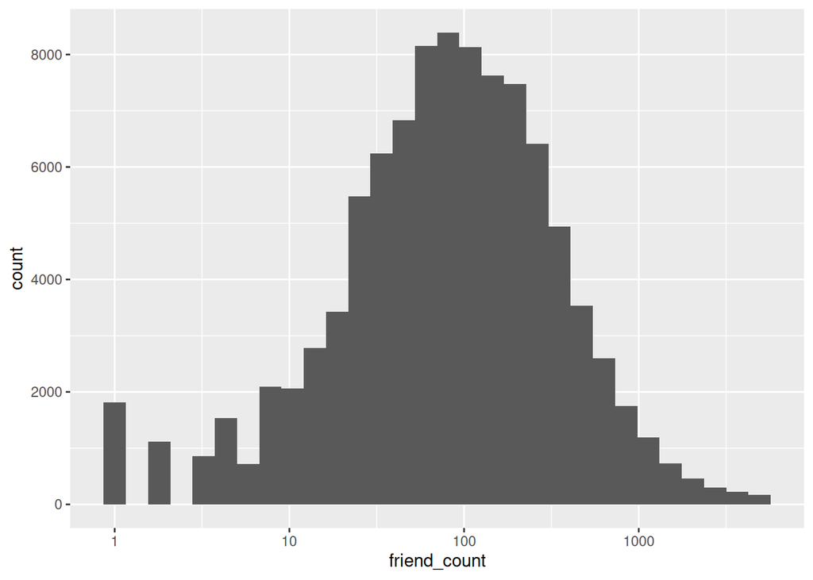

```r
ggplot(aes(x = friend_count), data = pf) +
  geom_histogram() +
  scale_x_log10()
```

### Frequency Polygons

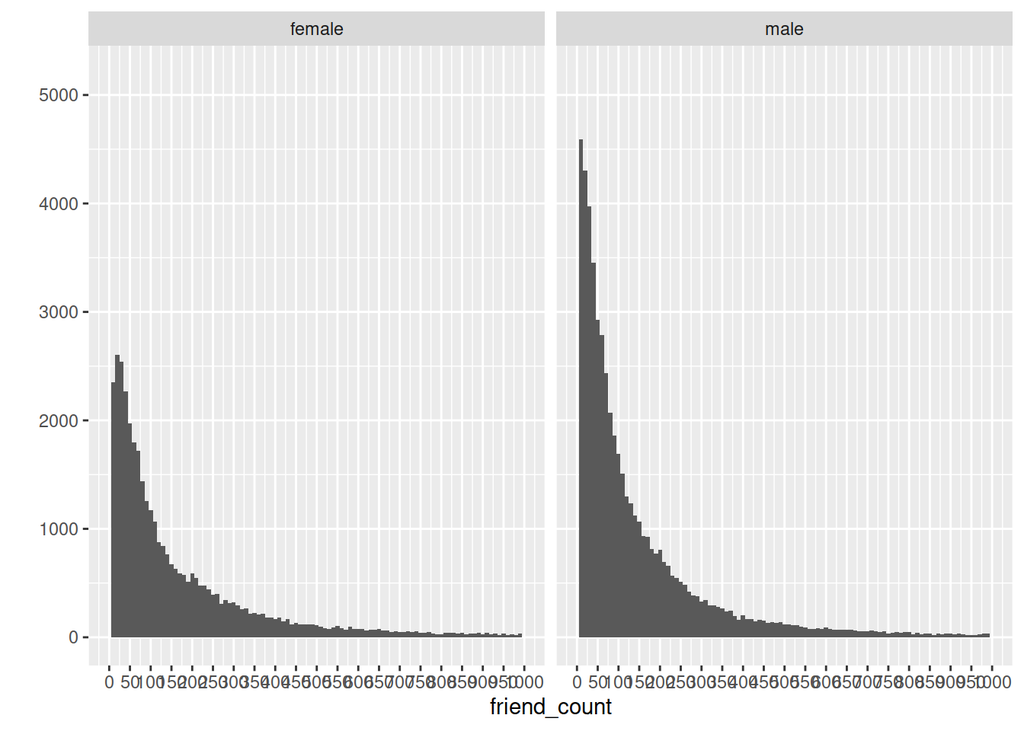

```r
qplot(x = friend_count, data = subset(pf, !is.na(gender)), binwidth = 10) +
  scale_x_continuous(limits = c(0, 1000), breaks = seq(0, 1000, 50)) +
  facet_wrap(~gender)
```

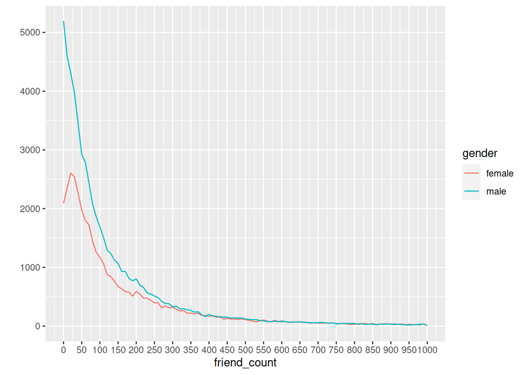

```r
qplot(x = friend_count, data = subset(pf, !is.na(gender)),
      binwidth = 10, geom = 'freqpoly', color = gender) +
  scale_x_continuous(limits = c(0, 1000), breaks = seq(0, 1000, 50))
```

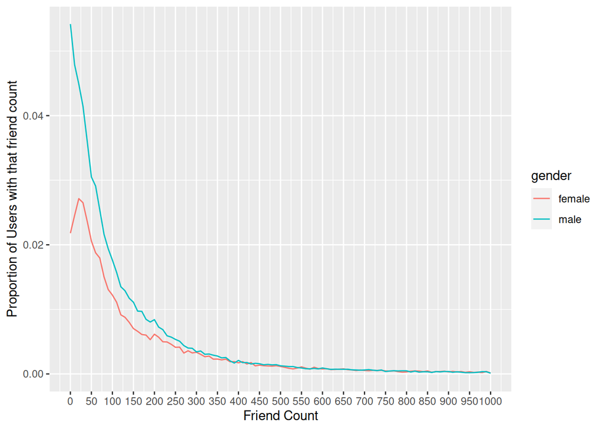

```r
qplot(x = friend_count, y = ..count../sum(..count..),
      data = subset(pf, !is.na(gender)),
      xlab = 'Friend Count',
      ylab = 'Proportion of Users with that friend count',
      binwidth = 10, geom = 'freqpoly', color = gender) +
  scale_x_continuous(limits = c(0, 1000), breaks = seq(0, 1000, 50))
```

In ggplot()

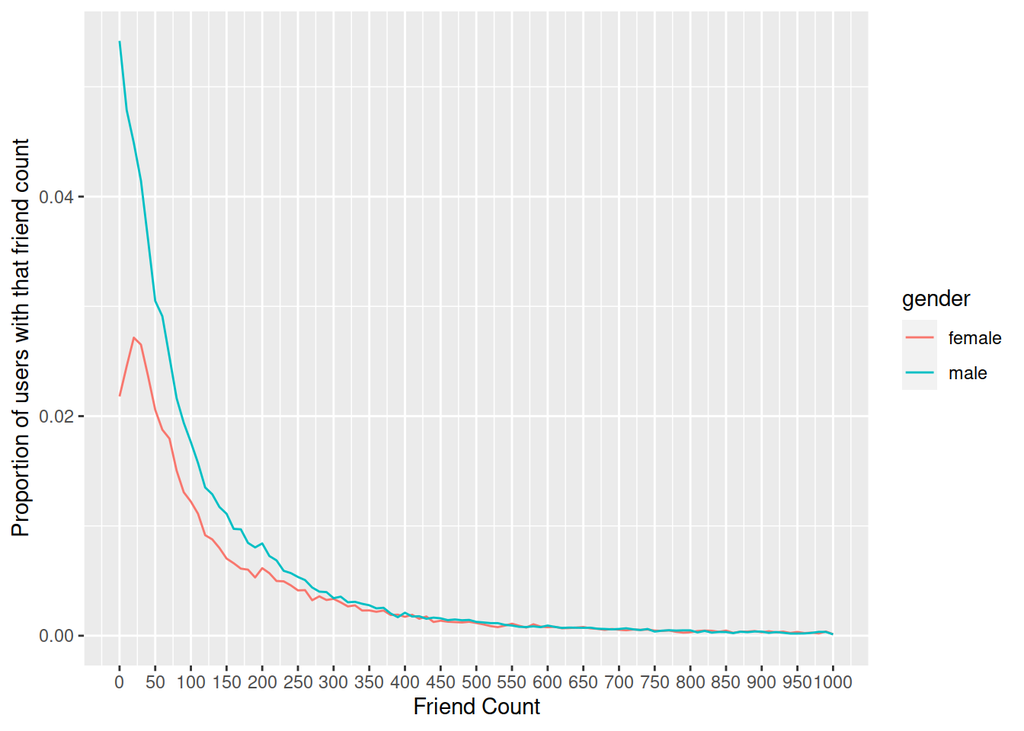

```r
ggplot(aes(x = friend_count, y = ..count../sum(..count..)),
       data = subset(pf, !is.na(gender))) +
  geom_freqpoly(aes(color = gender), binwidth=10) +
  scale_x_continuous(limits = c(0, 1000), breaks = seq(0, 1000, 50)) +
  xlab('Friend Count') +
  ylab('Proportion of users with that friend count')
```

### Likes on the Web